# 論文紹介 「Extra Chance Generalized Hybrid Monte Carlo」

- Campos, C. M., & Sanz-Serna, J. M. (2015). Extra chance generalized hybrid Monte Carlo. Journal of Computational Physics, 281, 365-374.

# Abstract

ハイブリッドモンテカルロ法と関連アルゴリズムにおける棄却を回避するために，Extra Chance Generalized Hybrid Monte Carlo法を研究した． 遅延棄却の精神では，棄却が起こるたびに，できれば受け入れられる新しい提案を見つけるために余分な作業が行われます． 著者らは，追加の機会アプローチで実行されたサンプル当たりの追加の仕事が，生成されたサンプルの品質に関して明らかに報いることを明確に示す実験を提示した．

Keywords: sampling methods, hybrid Monte Carlo, detailed balance, delayed rejection, rejection avoidance, molecular dynamics

# 1. Introduction

本論文では,ハイブリッドモンテカルロ(HMC)法 [8] とその変形(例[3，9，15–17])における棄却を回避するために,Extra Chance Generalized Hybrid Monte Carlo(XCGHMC)法を研究した． 統計学の文献では遅延棄却[12，20，32]と呼ばれていますが，棄却が発生するたびに，願わくば受け入れられるであろう新しい提案を見つけるための追加作業が行われます． 棄却は，アルゴリズムが正しいターゲット確率分布からサンプリングすることを保証するために不可欠であるが，サンプルの相関[22，31]の増加に寄与する． さらに,部分運動量リフレッシュ[15，17]を持つアルゴリズムでは,各棄却は必然的に運動量のフリップを必要とし,基礎となるハミルトニアン力学と干渉する． 著者らは,棄却を回避するために追加の機会アプローチで実施されたサンプル当たりの追加の仕事が,生成されたサンプルの品質に関して明らかに報いることを明確に示す実験を提示した．

ここで研究したアルゴリズムは数学的には[30]のSohl‐Dickstein,Mudigonda,DeWeeseによって示唆されたものと等価である． しかし,現在の研究における受容確率に対する実際の公式は[30]のものとは異なっている． ここで用いた式は，関係する確率についての洞察を与えるものである． さらに,特別なチャンスアルゴリズムが実際に詳細なバランス/確率的可逆性を満たすことを証明した．;これは驚くべきことである．[30]によれば，棄却を回避するためには詳細なバランスの侵害が必要である． Markov連鎖モンテカルロアルゴリズム[24]の性能と解析において,詳細なバランスは価値ある特性である． 例えば,著者らの実験([10]から取られる)で用いた有効サンプルサイズまたは自己相関時間の推定は,標的分布に関して可逆的である連鎖に依存する．

一方，[30]の基本的な考え方は，遅延棄却[12，20，32]と本質的に異なるものではない． しかしながら,HMCのいくつかの特異性(運動量フリップ，修正詳細バランス対標準詳細バランス，決定論的フローによって得られる提案)は,[30]またはここで考察したものと類似したアルゴリズムを考案または解析するために,[12，20，32]の材料を適用することを困難にするか,または不可能にさえする．

文献は，HMCにおける棄却/勢いの反転を避けるための示唆に欠けているわけではない．例えば，[1–3，29，33]を参照． これらの手法と特別なチャンスアプローチとの比較は，ここでは取り上げません． [7] で行われたように，我々はHMCを他のサンプリングアルゴリズムと比較することにも関心を持たない．

セクション2では，追加のチャンスアルゴリズムを示す． 第3章は受容確率の分析に当てられている． 概念実証数値実験については，セクション4およびセクション5の結論で報告する． より多くの数学的な結果が付録A~Cに示されている．

# 2. Algorithm

## $\mathrm{I}(z)$を計算

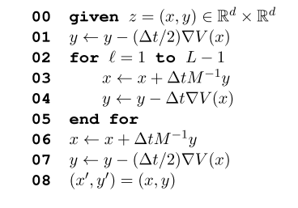

- 図1は，初期点$z$から始まる長さ$Δt>0$の$L$積分時間ステップの結果$z’=(x’，y’)=\mathrm{I}(z)$を計算するための擬似コードを示す．
  - 相空間をそれ自身に写像する変換$\mathrm{I}$は体積保存(すなわち，単位ヤコビ行列式を持つ)と可逆の両方である．
  - 可逆性とは，各$z’$について，$\mathrm{I}^{−1}(z')=F(\mathrm{I}(F(z')))$であることを意味し，ここで，Fは運動量フリップ変換を表し，$F(x,y)=(x,-y)$である．
  - したがって，数値積分の初期点$z=\mathrm{I}^{−1}(z')$を回復するには，運動量を反転させ，$L$(前進する)の時間ステップをとり，再び運動量を反転させれば十分である．これは (5) の真の解の流れの基本的な性質に正確に一致する．
  - なお，$F$は体積保存であり，さらに$H(z)=H(F(z))$である．

## XCGHMCアルゴリズム

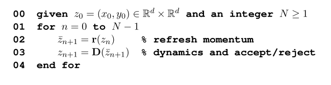

- XCGHMCアルゴリズムを図2にまとめ，
  - 式(4)の$ρ$ が鎖$z_0→z_1→・・・→z_N$の不変密度であることの証明を付録Aに示す．
  - 付属書Bでは，$y_0\sim \mathrm{N}(0，M)$の場合，$x$成分をとって得られる辺縁鎖$x_0→x_1→・・→x_N$が， 目標分布 (1) に対して詳細なバランスを満たすことを示している．
  - 序文で指摘したように，図2のアルゴリズムは[30]で示唆されているものと数学的に等価である．付録Cを参照してください．
  - 付録の材料は，体積保存と可逆性である$\mathrm{I}$に依存しており，それ以外の点では速度ベルレ積分器の特性とは無関係であることを指摘するためである．したがって，図2に示した別の積分器を用いることも可能である．ただし，それらの積分器が体積保存型であり，かつ可逆的であることが条件である．
- 図2のチェーンの各ステップの計算は，二つのサブステップ，運動量リフレッシュ$r$と動力学(受け入れ/棄却メカニズムを含む)$D$を含む．

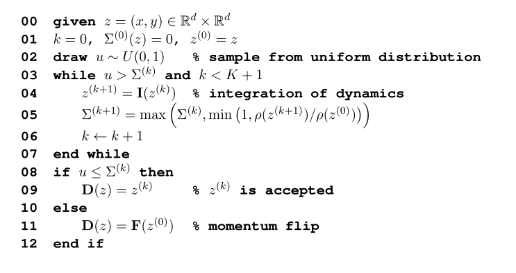

- 図3に(無作為の)変換$D$の計算を示す．
  - (無作為の)マッピングrは，次のように定義される．$z=(x,y)$の場合，$r(z)$を評価するために，分布$\mathrm{N}(0，M)$((4) 参照)から実現値$ζ$を求め，以下のように設定する．
    $$\begin{eqnarray}
    r(z) = (x, \cos\psi\ y + \sin\psi\ \zeta)
    \end{eqnarray}$$
    ここで，$ψ$はユーザー指定パラメータ$0<ψ≤π/2$です．
  - $ψ=π/2$のとき，$r$の効果は古い運動量を$y$の周辺分布の新しい標本で置き換えることである． $ψ$間隔の他端で$ψ≒0$を選ぶと，$r(z)$の運動量は[15，17]で示唆されているように$y$の小さなランダム摂動となる．

## パラメータ

- 図2の全体的なアルゴリズムは，パラメータとして質量行列$M$と数$L，Δt，ψ，K$を持つ．値はユーザーが設定する必要があります．
  - 実際，$M，L，Δ，ψ$は，XCGHMCでも一般HMC(GHMC)と同じ役割を果たしている．
  - どのようにして最善の選択をするかという困難な問題を議論することは，現在の貢献の範囲内ではない．
  - 関連文献は，$M$の選択については[5，11]，$Δ$については [4]，$L$については[14]，$ψ$については[15]である．

## $K$の役割

### $K=0$

- ここで示すように，$K=0$(追加のチャンスなし)を選択すると，図2のアルゴリズムはGHMCになり，したがって$ψ=π/2$(完全なモメンタムリフレッシュ)を加えると標準HMCになる．
  - 実際，$K=0$の場合，図3のループ03-07は，マルコフ連鎖の遷移$n→n+1$毎に1回実行される．
  - 数値積分を行って，提案された状態$z^{ (1)}=\mathrm{I}(\bar z_{n+1})$を見つけ， 連鎖の次の位置$z_{n+1}$は，提案$\mathrm{I}(\bar z_{n+1})$(引受け)と確率で一致する．
    $$\begin{eqnarray}
    \Sigma^{(1)} =
    \mathrm{\mathrm{min}}\left(1,\frac{\rho(\mathrm{\mathrm{I}}(\bar z_{n+1}))}{\rho(\bar z_{n+1})}\right).
    \end{eqnarray}$$
  - 棄却の場合，次の位置は$z_{n+1}=F(\bar z_{n+1})$である．
  - いずれの場合も，XCGHMCの受容と棄却の結果はGHMCの結果と一致する．
- $ψ$の値にかかわらず，棄却は$x_{n+1}=x_{n}$であることを意味し，これがサンプルの相関の増大に寄与している．
- 棄却は，アルゴリズムが正しい分布からサンプリングするために必要であるが，歓迎されない．
- さらに，$\psi$の選択が分子動力学シミュレーションで興味があるように，軌道$z_0,z_1,..z_N$がハミルトニアン動力学を近似するという希望をもって，$r$がほとんど運動量を保存するよう$ψ$を小さく選択した場合を考察せよ。
- この場合，棄却が運動量の反転を意味するという事実は$ψ$の選択の根拠と衝突するので，特に厄介である．

### $K=1$

- ここで$K=1$(追加機会)という選択を考えてみよう．
- 再び遷移$n→n+1$を考え，与えられた$\bar z_{̄n+1}$と$u$(図3参照)に対して， 標準GHMCアルゴリズムを用いた場合には提案$\mathrm{I}(\bar z_{n+1})$が受け入れられたと仮定する．
- この仮定の下では，XCGHMCは図3のループ03-07を一度だけ通過し，$z_{n+1}=\mathrm{I}(\bar z_{n+1})$と設定する．
- 一方，与えられた$\bar z_{̄n+1}$と$u$に対して, 提案$\mathrm{I}(\bar z_{n+1})$は標準GHMCアルゴリズムでは棄却されるであろうが，XCGHMCは$n→n+1$遷移における運動量フリップを避ける追加の機会を提供する．
- 実際には，ループ03-07は2回目に実行されます． 点$z^{ (1)}=\mathrm{I}(\bar z_{n+1})$から$z^{ (2)}$ を求め，$Σ^{ (2)} ≥u$の場合，次の位置は$F(\bar z_{n+1})$ではなく$z_{n+1}=\mathrm{I}(\mathrm{I}(\bar z_{n+1}))$となる．

## 用語について

- 論文[30]では，その戦略を説明するために，look aheadという言葉を使っている． 提案$\mathrm{I}(\bar z_{n+1})$を受け入れるためには， $\mathrm{I}^2(\bar z_{n+1}) = \mathrm{I}(\mathrm{I}(\bar z_{n+1})), \mathrm{I}^3(\bar z_{n+1}) = \mathrm{I}(\mathrm{I}(\mathrm{I}(\bar z_{n+1}))),...$の前方の点を見る必要があることを示唆するので，この用語は誤解を招く可能性がある．
- 統計学の文献で使用されている用語‘delayed rejection’ [12，20，32]もまた，やや不明確である．目標は棄却を回避することであり，後に棄却することではない．

# 3. The acceptance probabilities

$D$のaccept/reject戦略をさらに検討してみましょう． $z$を固定し，単調数列
$$0=\Sigma^{(0)}(z) < \Sigma^{(1)}(z)\le\cdots \le\Sigma^{(K+1)}(z)\le 1$$
を以下のように定義する(cf．図3の行05)

- なお実際のアルゴリズムは点$\mathrm{I}^{k−1}(z)$が棄却されない限り，$Σ^{(k)} (z)$を計算しない．

$$\begin{eqnarray}
\Sigma^{(k)}(z)
&=&
\mathrm{\mathrm{max}}\left(\Sigma^{(k-1)}(z),\ \mathrm{\mathrm{min}}\left(1,\frac{\rho(\mathrm{\mathrm{I}}^k(z))}{\rho(z)}\right)\right),\
k=1,\ldots,K+1.\\
&=&
\mathrm{\mathrm{max}}_{1\le j\le k}\mathrm{\mathrm{min}}\left(1,\frac{\rho(\mathrm{\mathrm{I}}^j(z))}{\rho(z)}\right)\\
&=&
\mathrm{\mathrm{min}}\left(1,\mathrm{\mathrm{max}}_{1\le j\le k}\frac{\rho(\mathrm{\mathrm{I}}^j(z))}{\rho(z)}\right).
\end{eqnarray}$$

- 図3から，
  $$D(z) = \mathrm{I}(z)，\mathrm{I}^2(z)，..,\mathrm{I}^k(z) \Leftrightarrow u≤Σ^{(k)}(z).$$
- 結果として$D(z) = \mathrm{I}^k(z)$である確率$p^{(k)}(z)$は，
  $$\begin{eqnarray}
  p^{(k)}(z) = \Sigma^{(k)}(z) - \Sigma^{(k-1)}(z),\ k=1,\ldots,K+1.
  \end{eqnarray}$$
- また$D(z)=F(z)$となる確率$p^{(K+2)}(z)$は，
  $$\begin{eqnarray}
  p^{(K+2)}(z) = 1 - \Sigma^{(K+1)}(z).
  \end{eqnarray}$$
- つまり値$Σ^{ (k)} (z)$は、区間$[0,1]$を長さ$p^{(k)}(z)$である$K+2$個の部分区間に分割し、$D(z)$が$\mathrm{I}(z)，..,\mathrm{I}^{k+1}(z),F(z)$となる確率それぞれを与える．
  - 部分区間のいくつかは1点に退化し，対応する結果は確率0を持つ．

以下の結論に留意する．

1. $ρ(\mathrm{I}^k(z)) < ρ(\mathrm{I}^j(z)), j<k$とする． このとき，$Σ^{ (k)} (z) = Σ^{(k−1)}(z)$であり，$D(z) = \mathrm{I}^k(z)$となる確率$p^{(k)} (z)=0$である． 言い換えると$D(z)$は、$\rho$の値が直前のすべての位置の値よりも大きくなる位置$\mathrm{I}^k(z)$だけに移動する。
2. ある位置で$ρ(\mathrm{I}^j(z))>ρ(z), 1≤j≤k$と仮定する。この場合、$Σ^{ (k)} (z)=1$となり、したがって、$\mathrm{I}(z),\mathrm{I}^2(z),.....，\mathrm{I}^k(z)$のうちの1つが受け入れられます。このとき運動量フリップ$D(z)=F(z)$は生じない。

## 条件付き確率ではない

- 遅延拒絶に関する文献TiMi99、Mi01、GrMi01と現在のアプローチを比較するとき、上記で定義された確率$Σ^{ (k)} (z)$と$p^{ (k)} (z)$は条件付きではない。
- 私たちは，$\mathrm{I}(z)$を棄却したという条件のもとで$\mathrm{I}^2(z)$を採択する確率には関心を持っていない。
- これを、同じステップでの以前の試みが拒絶されたことを条件として、新しい試みを受け入れる確率に焦点を当てたアプローチ[12，20，32]と比較する。 このような条件付き確率の公式はあまりうまくないことがわかった。

# 4. Numerical results

# 5. Conclusion

# A. Stationarity of the Markov chain

この付録では，分布(4)
$$\begin{eqnarray}
\rho(z) = \exp(-\beta H(z)) = \exp(-(\beta/2)\ ^tyM^{-1}y)\times \exp(-\beta V(x))
\end{eqnarray}$$
が図2

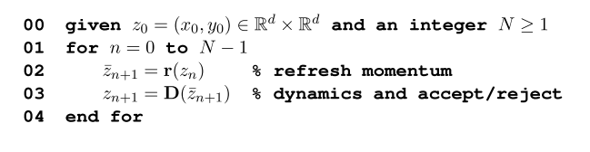

の鎖に対して不変であることを証明する．

- $ρ$は$r$に対して不変であることは明らかなので，$D$に対して不変であることを示せば十分である．
- このような不変性は，修正された詳細バランスの要求によって暗示されることがよく知られている(例[9，19，26]参照)．
  $$ρ(z ) ρ(z' | z ) = ρ(\mathrm{F}(z' )) ρ(\mathrm{F}(z ) | \mathrm{F}(z' )).\ \mathrm{(A.1)}$$
- ここで，$ρ(z'|z)$は，$z$を条件とする$z'=D(z)$の条件付き分布を示し，$ρ(\mathrm{F}(z)|\mathrm{F}(z'))$は，$\mathrm{F}(z')$を条件とする$\mathrm{F}(z)=D(\mathrm{F}(z'))$の条件付き分布を示す．
- (A .1)を確立するために，我々は，位相空間における各$z$および$k=1,..$に対して有効である，次の同一性を使用する．この付録の最後で証明されます．
  $$ρ(z ) p^{(k)} (z ) = ρ(\mathrm{F}(\mathrm{I}^k (z ))) p^{(k)} (\mathrm{F}(\mathrm{I}^k (z ))).\ \mathrm{(A.2)}$$
- $D$の定義により，(A.1)の左辺と右辺を書き換える．それぞれ，

$$ρ(z )\left( \sum_{k =1}^{K +1} p^{(k)} (z ) δ(z' − \mathrm{I}^k (z ))
+ p^{(K +2)} (z ) δ(z' − \mathrm{F}(z )) \right), \\
ρ(\mathrm{F}(z' ))\left( \sum_{k =1}^{K +1} p^{(k)} (\mathrm{F}(z' )) δ(\mathrm{F}(z ) − \mathrm{I}^k (\mathrm{F}(z' )))
+ p^{(K +2)} (\mathrm{F}(z' )) δ(\mathrm{F}(z ) − \mathrm{F}(\mathrm{F}(z' ))) \right).$$

- これらの式の最後の項は一致しているので，$k=1.., K+1$の各項で等号成立を示せばよい．
  $$ρ(z ) p^{(k)} (z ) δ(z' − \mathrm{I}^k (z ))
  = ρ(\mathrm{F}(z' )) p^{(k)} (\mathrm{F}(z' )) δ(\mathrm{F}(z ) − \mathrm{I}^k (\mathrm{F}(z' ))).$$
- これは，$\mathrm{I}$の可逆性が暗示するように，(A .2)の結果である．
  $$δ(\mathrm{F}(z ) − \mathrm{I}^k (\mathrm{F}(z' ))) = δ(z − \mathrm{F}(\mathrm{I}^k (\mathrm{F}(z' )))) = δ(z' − \mathrm{I}^k (z ))$$
  $\mathrm{F}$と$\mathrm{I}^k$の両方が体積保存であるからである．
- これで(A .1)が証明できた．

## (A .2)の証明

# B. Detailed balance

- 上記で証明されたように、$D$の1ステップでは、修正された詳細バランスを満たすが、図2のチェーン全体ではそうではない．
- 論文[FaSaSkl14]は、関連する反例を提示し、また、図B.8のように、遷移$n→n+1$に回文構造を課すことによって、修正された詳細なバランスが達成されることを示す。

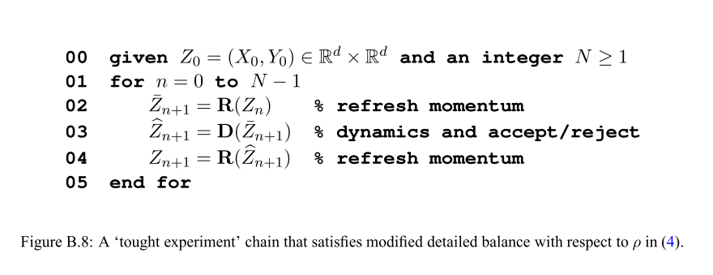

- コードライン02と04は、$r(z) = (x, \cos\psi\ y + \sin\psi\ \zeta)$のように運動量をリフレッシュする。
- 大文字$R$の使用は、図B.8が図2の$\psi$とは異なる角度$\Psi,0<\Psi \leq \pi/2$を使用し得ることを示す。
  $$R(Z) = (X, \cos \Psi\, Y+\sin\Psi\, \zeta).$$
- 実際、以下では、$\Psi$は式$\cos^2\Psi=\cos \psi$によって$\psi$の関数として決定されると仮定する。

## $x_n$と$X_n$は同じ周辺鎖

- 次に、実際に実装されたXCGHMCの連鎖 (図2) と、図B.8の連鎖は、位置$x_n$または$X_n$に対して同じ周辺鎖を生じさせることを示す．
  - したがって、XCGHMCの位置$x_n$の連鎖は、
    $$\begin{eqnarray}
    \frac{1}{Z}\exp(-\beta V(x)),\
    Z = \int_{\mathbb{R}^d}\exp(-\beta V(x))dx\ (1)
    \end{eqnarray}$$
    に対して可逆的となる。
- 図B.8の連鎖の実現について考えてみよう。
  - これは、$Y_0\sim \mathrm{N}(0，M)$を有する開始位置$X_0,Y_0$や、ステップ02,03および04でそれぞれ使用されるランダム変数の実現$\bar \zeta_{n+1},u_{n+1},\hat \zeta_{n+1}$のことである。
- これらの実現値により、XCGHMC連鎖の実現を以下のように定義します。

$$\begin{eqnarray*}
x_0&=&X_0,\\
y_0 &=& \cos(\psi-\Psi)\, Y_0-\sin(\psi-\Psi)\bar \zeta_1,\\
\zeta_1 &= & \sin (\psi-\Psi)\, Y_0+ \cos(\psi-\Psi)\bar \zeta_1,\\
\zeta_{n+1} & = & (1/\sin \psi) (\cos \Psi\, \sin\Psi \hat \zeta_n+ \sin \Psi \bar \zeta_{n+1}),\quad n = 1,\dots, N-1,
\end{eqnarray*}$$

- 図2のステップ02と03で$r$と$D$をそれぞれ計算するとき、$\zeta_{n+1}$と$u_{n+1},n=0,\dots,N-1$を使用します。
  - これは、簡単にチェックできるように、$\zeta_n \sim \mathrm{N}(0，M)$であるため、正当であることに注意してください。
- $y_0$および$\zeta_1$の定義より，$\bar z_1=\bar Z_1$となり、$z_1=D(\bar z_1) = D(\bar Z_1) = \hat Z_1$となる。
  $$\bar z_1 = (x_0, \cos\psi\ y_0+\sin\psi\ \zeta_1) = (X_0, \cos\Psi\ Y_0 + \sin\Psi\ \bar\zeta_1) = \bar Z_1$$
- 次に、$\zeta_2$を選択することにより、$\bar z_2=r(z_1)$を得るための運動量リフレッシュが、$\bar Z_2=R( Z_1)=R(R(\hat Z_1))$を計算するための2つの運動量リフレッシュと同じ出力を生成することが保証される。
  $$\begin{eqnarray*}
  \cos\Psi(\cos\Psi\ Y_0 + \sin\Psi\ \hat\zeta_1) + \sin\Psi\ \bar\zeta_2
  &=& \cos^2\Psi\ Y_0 + \cos\Psi\sin\Psi\ \hat\zeta_1 + \sin\Psi\ \bar \zeta_2 \\
  &=& \cos\psi\ Y_0 + \sin\psi\ \zeta_2
  \end{eqnarray*}$$
- この議論を繰り返すと、$n=1, ..,N$に対して$z_n=\hat Z_n$であるから，$x_n=X_n$となる．
- サンプル$x_n$が図B.8の回文鎖に由来するとみなすことができた。

# C. Equivalence of XCGHMC and the algorithm by Sohl-Dickstein et al.

[30]では,実際にXCGHMCと等価なLook Ahead Hybrid Monte Carlo(LAHMC)と呼ばれるアルゴリズムを導入した． ここで，$z^{ (k)}$ への遷移確率は次のように定義される．
$$π^{(k)} (z ) = \mathrm{min}
\left(1 − \sum_{1≤j ≤k −1} π^{(j )} (z ),\
\frac{ρ(\mathrm{F} \mathrm{I}^k (z ))}{ρ(z )}\left(1− \sum_{1≤j ≤k −1} π^{(j )} (\mathrm{F} \mathrm{I}^k (z )) \right)
\right), \\
k = 1, . . . , K + 1.$$
XCGHMCとLAHMCが等価であることを示すためには，累積確率が
$$S^{(0)} (z ) = 0,\ S^{(k)}(z ) = \sum_{1≤j ≤k}π^{(j )} (z ),\ k = 1, . . . , K + 1.$$
任意の点$z$におけるすべての$k$について (8) の$Σ^{ (k)}$ と一致する． 単純な操作によって，これが$k=1$の場合に真であることが証明される;一般的な場合は帰納によって証明される． 約$1≤k−1≤K$までのアサーションが真であると仮定し，それが$k$について成り立つことを示す． 文字を明るくするために，
$$M^{ (k)} (z ) = \mathrm{max}_{1≤j ≤k}\frac{ρ(\mathrm{F} \mathrm{I}^j (z ))}{ ρ(z )}
= \mathrm{max}_{1≤j ≤k}\frac{ρ(\mathrm{I}^j (z ))}{ρ(z )}.$$
定義によれば
$$\begin{eqnarray}
S^{ (k)} (z )
&=& S^{ (k−1)} (z ) + \mathrm{min}\left( 1 − S^{ (k−1)} (z ), \frac{ρ(\mathrm{F} \mathrm{I}^k (z ))}{ρ(z )}\left(1 − S ^{(k−1) }(\mathrm{F} \mathrm{I}^k (z ))\right)\right)\\
&=& \mathrm{min}\left( 1, \frac{ρ(\mathrm{F} \mathrm{I}^k (z ))}{ρ(z )}\left(1 − S^{ (k−1)} (\mathrm{F} \mathrm{I}^k (z ))\right) + S^{ (k−1)} (z )\right)\\
&=& \mathrm{min}\left( 1, \frac{ρ(\mathrm{F} \mathrm{I}^k (z ))}{ρ(z )}\left( 1 -\mathrm{min}\left(1, M^{ (k−1)} (\mathrm{F} \mathrm{I}^k (z ))\right)\right) + S^{ (k−1)} (z )\right)\\
&=& \mathrm{min}\left(1, \mathrm{max}\left(0, \frac{ρ(\mathrm{F} \mathrm{I}^k (z ))}{ρ(z )} - M^{ (k−1)} (z )\right) + S^{ (k−1)} (z ) \right),
\end{eqnarray}$$
ここでは，第三の等式において$S^{(k−1)}(\mathrm{F} \mathrm{I}^k(z))$の帰納仮説を用い，
$$ρ(z ) M^{ (k−1)} (z ) = ρ(\mathrm{F} \mathrm{I}^k (z )) M^{ (k−1) }(\mathrm{F} \mathrm{I}^k (z ))$$
最後の等式で($ρ$は$\mathrm{F}$の下で不変であり，$\mathrm{I}^j \mathrm{F} \mathrm{I}^k=\mathrm{I}^{k−j}$であることを思い出そう)． ここで，二つの可能性が生じる．$S^{(k−1)}(z)<1$または$S^{(k−1)}(z)=1$である．$S^{(k−1)}(z)<1$の場合には，$S^{(k−1)}(z)=M^{(k−1)}(z)$という帰納仮説が成立する．
$$S^{ (k)} (z ) = \mathrm{min}\left(1, \mathrm{max}\left( M^{ (k−1)} (z ), \frac{ρ(\mathrm{F} \mathrm{I}^k (z ))}{ ρ(z )}\right)\right).$$
逆に，$S^{(k−1)}(z)=1$であれば，帰納仮説は$M^{(k−1)}(z)≥1$であることを意味する．
$$S^{ (k)} (z ) = 1 = \mathrm{min}\left(1, \mathrm{max}\left( M^{ (k−1)} (z ), \frac{ρ(\mathrm{F} \mathrm{I}^k (z ))}{ ρ(z )}\right)\right).$$
したがって，どちらの場合も
$$S^{ (k)} (z )
= \mathrm{min}\left(1, \mathrm{max}\left( M^{ (k−1)} (z ), \frac{ρ(\mathrm{F} \mathrm{I}^k (z ))}{ ρ(z )}\right)\right)
= \mathrm{min} \left(1, M^{ (k)} (z )\right) ,$$
これで証明は完了です．

我々の見解では，$π^{ (k)}$ の確率ではなく，XCGHMCのように累積された確率を扱うことは，第3節のように理論的な洞察をより良くするだけでなく，コードをより単純なものにする．